# TP02- Preprocesamiento con R

Agustín normand

24 Septiembre 2021

## Limpieza de datos:

### 1. Datos faltantes

#### a. Verifique cual es la proporción de valores faltantes respecto a la cantidad total de instancias del dataset.

Cantidad de instancias en el dataset.

```
## [1] 5891
```

Cantidad de datos faltantes para el atributo *tiempo_translado*.

```
## [1] 863
```

Proporción de datos faltantes respecto a la cantidad total de instancias del dataset. Redondeada a 2 decimales.

```
## [1] 14.65
```

#### b. Genere un nuevo atributo utilizando solo los registros con valores observados para el atributo.

Omito los nulos utilizando la siguiente línea de código.

```r
tiempo_traslado_reg_completos<-na.omit(encuesta_universitaria$`'Tiempo_Traslado'`)
```

Si ahora vemos la cantidad de filas del dataset resultante. Podemos comprobar que efectivamente eliminó las filas que contenían *missing values*, ya que la cantidad es menor a la calculada anteriormente.

```
## [1] 5028
```

Para terminar de comprobar que los faltantes fueron eliminados, si contamos la cantidad de faltantes, da como resultado 0.

```
## [1] 0
```

#### c. Genere un nuevo atributo en el que sustituya los valores faltantes por la media encontrada para el atributo.

Genero un nuevo atributo con el nombre *media*, y reemplazo los valores faltantes, por el valor de la media del *Tiempo de traslado*.

```r
encuesta_universitaria_imp<-encuesta_universitaria
encuesta_universitaria_imp$media <- encuesta_universitaria$`'Tiempo_Traslado'`
encuesta_universitaria_imp$media[is.na(encuesta_universitaria_imp$media)]<-mean(encuesta_universitaria_imp$media, na.rm = TRUE)
```

Si cuento la cantidad de faltantes del atributo *media*, podemos comprobar que da 0.

```
## [1] 0
```

#### d. Genere un nuevo atributo en el que sustituya los valores faltantes de acuerdo al método de “hot deck imputation”.

Defino un dataframe auxiliar para no perder el *Tiempo de Traslado* original, asigno el resultado del hotdeck en un atributo llamado *hotdeck* y creo un flag llamado *hotdeckbool* que indica si fue imputado o no el dato.

```r
df_aux<-hotdeck(encuesta_universitaria, variable="'Tiempo_Traslado'")
encuesta_universitaria_imp$hotdeck<-df_aux$`'Tiempo_Traslado'`
encuesta_universitaria_imp$hotdeckbool<-df_aux$`'Tiempo_Traslado'_imp`
```

Si cuento la cantidad de faltantes del atributo *hotdeck* podemos comprobar que da 0.

```
## [1] 0
```

#### e. Genere un nuevo atributo en el que sustituya los valores faltantes de acuerdo al método de “hot deck imputation”.

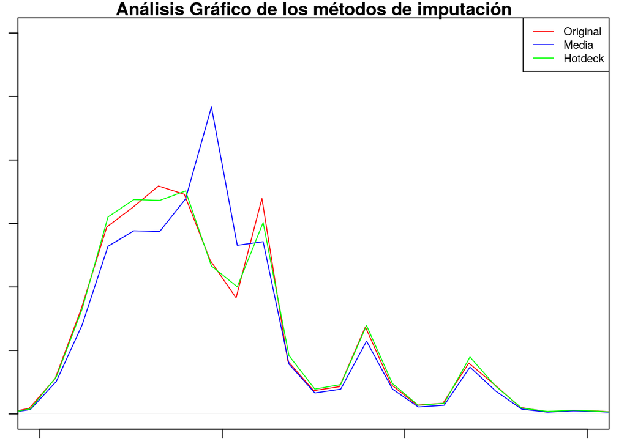

**Observaciones:**

- (Línea azul) Se puede observar como se ve influenciada la distribución de los datos con imputaciones a través de la media. Ya que estoy estableciendo un único valor para garantizar la continuidad de los datos. Obviamente, aumenta la frecuencia donde tengo ubicada la media.
- (Línea roja) Los datos originales y los imputados mediante *hotdeck* (Línea verde), se puede ver que respeta la distribución de la variable.

### 2. Manejo de Ruido

#### a. Verifique en primer lugar la distribución de los datos, utilice algún método gráfico para esto.

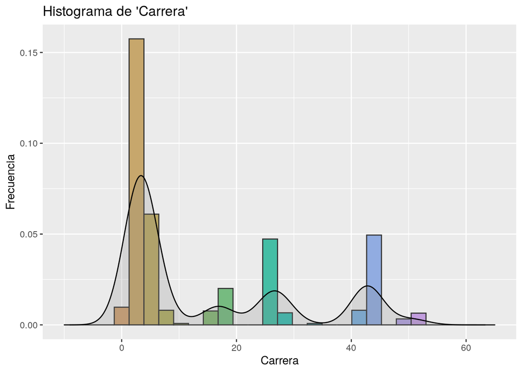

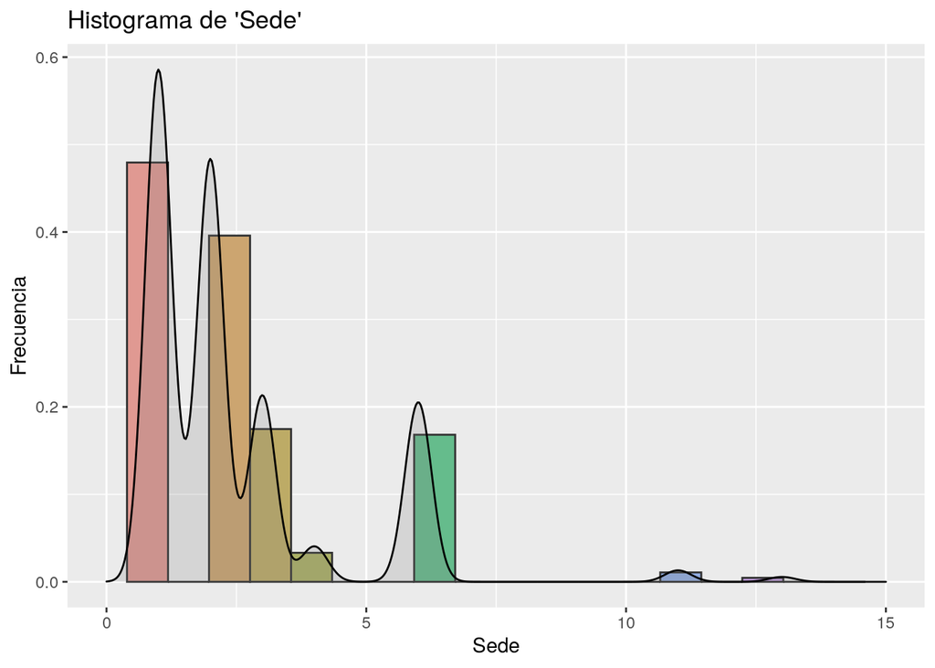

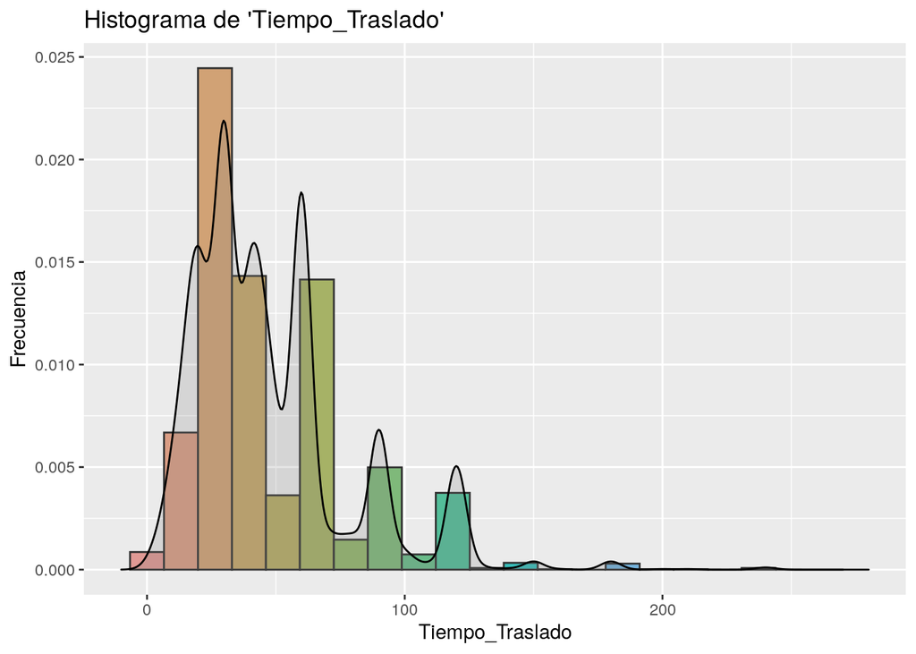

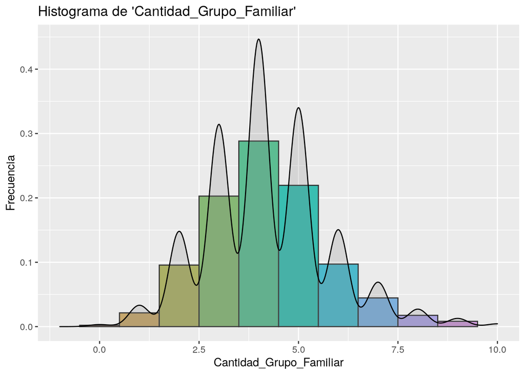

Se puede observar que el histograma de *Cantidad Grupo Familiar* se asemeja a una distribución normal.

#### b. Realice un suavizado utilizando *binning* por frecuencias iguales (con 5 bins) y estime el valor del bin por el cálculo de medias.

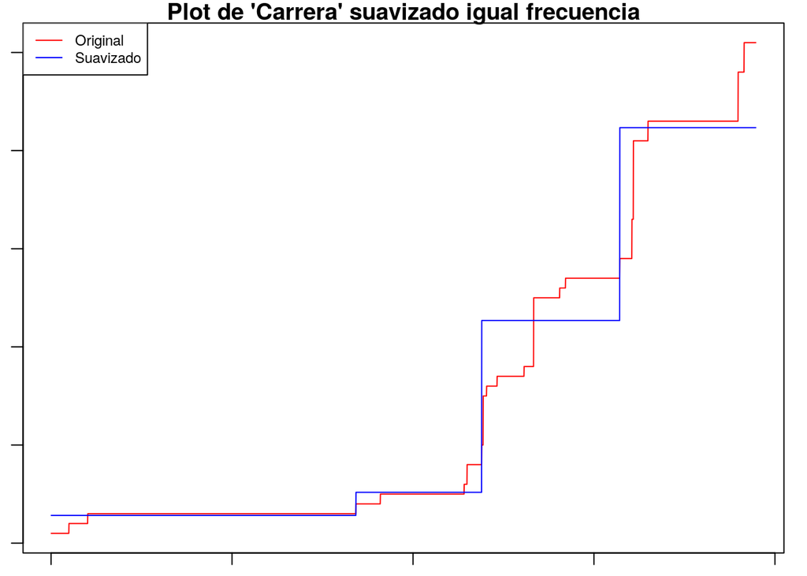

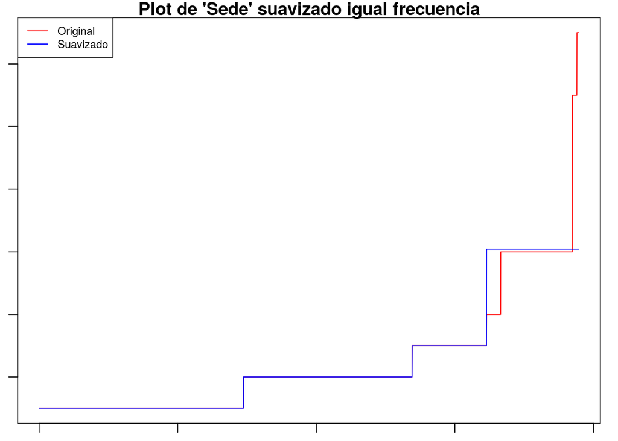

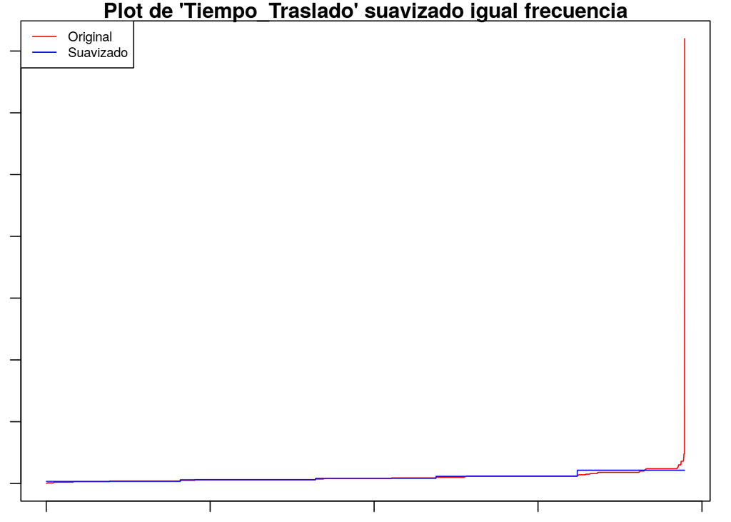

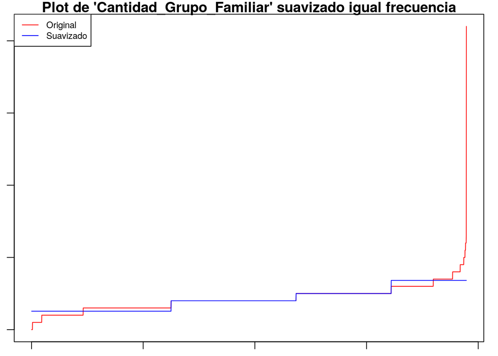

#### c. Ahora, realice el suavizado por anchos iguales (con 5 bins) y compare los resultados gráficamente.

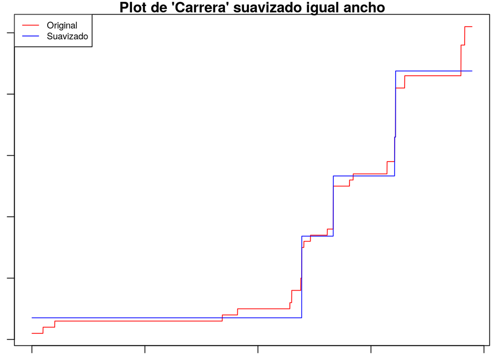

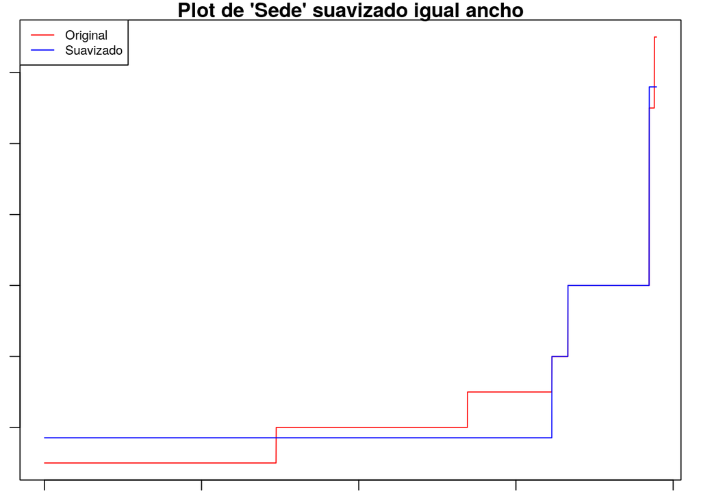

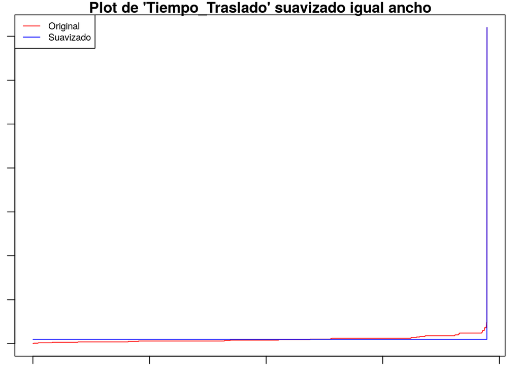

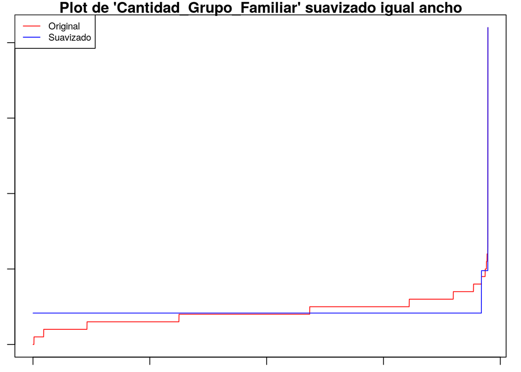

### 3. Detección de outliers

#### a. Verifique la existencia de *outliers* en el atributo *tiempo_traslado* en función del resto de los atributos. ¿En todos se trata de un valor anómalo?

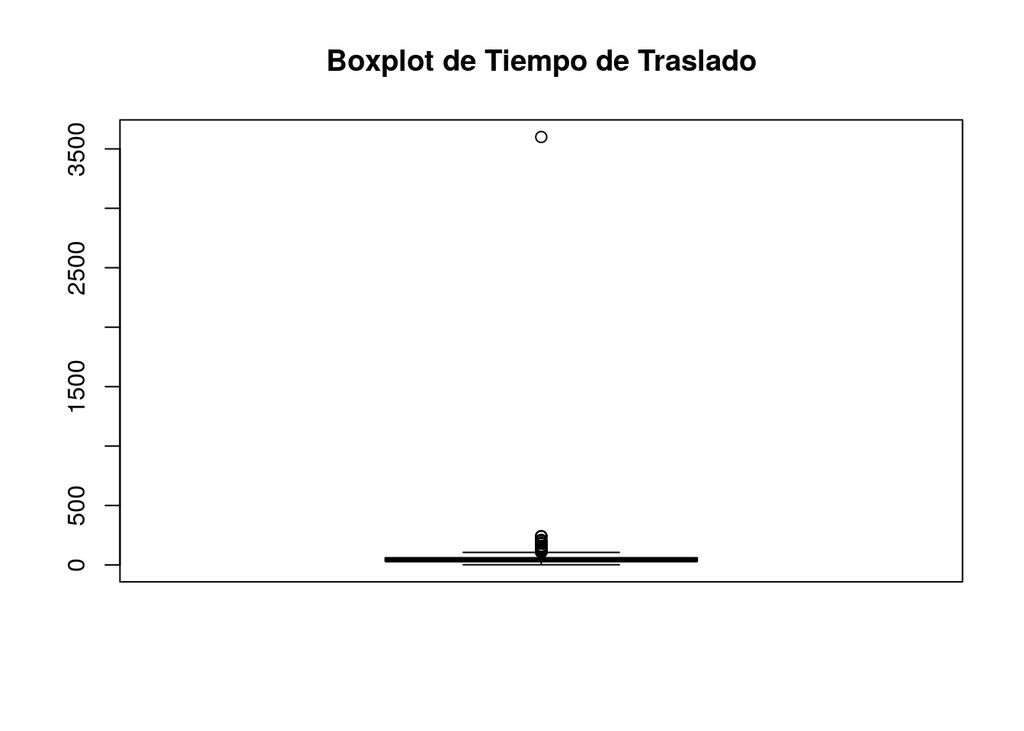

Podemos observar la existencia de *outliers* en el atributo *tiempo_traslado*

Si bien en el gráfico se puede observar aproximadamente de qué valor se trata, lo obtengo con la funcion *max*.

```
## [1] 3600
```

Obtengo las filas cuyo valor de *tiempo_traslado* es 3600

```r
outlier<-na.omit(encuesta_universitaria[encuesta_universitaria$`'Tiempo_Traslado'`==3600, ])
```

Cuando se trata del atributo *Carrera* el valor es:

```
## [1] 1
```

Y el boxplot correspondiente a dicho atributo es:

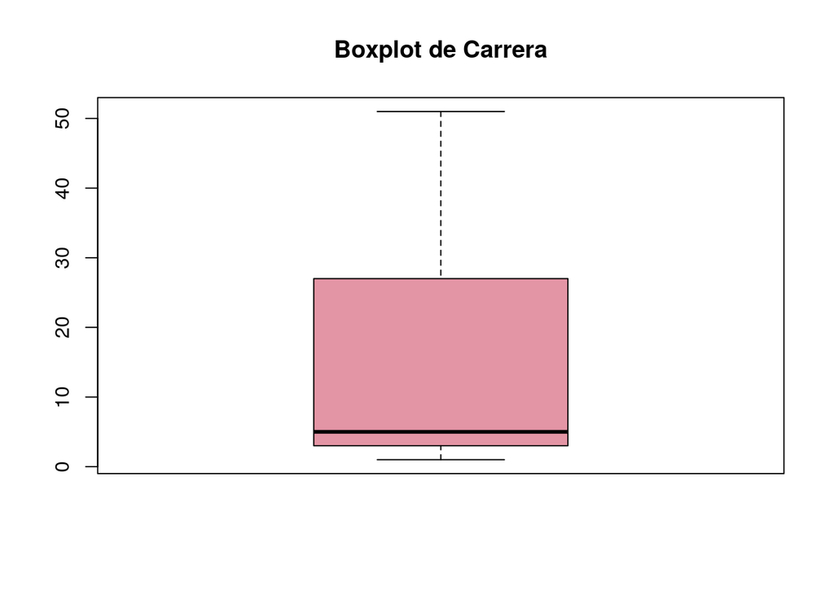

Por lo tanto podemos afirmar que no se trata de un *outlier* para el atributo *Carrera*.

Realizando este mismo análisis para el resto de los atributos, se puede concluir que no en todos los casos se trata de un valor anómalo.

#### b. Aplique las técnicas de análisis y detección vistas en clase: IRQ, SD(seleccione el N que mejor se adapte a su criterio) y Z-Score (seleccione el umbral que mejor se adapte a su criterio)

##### Método IRQ

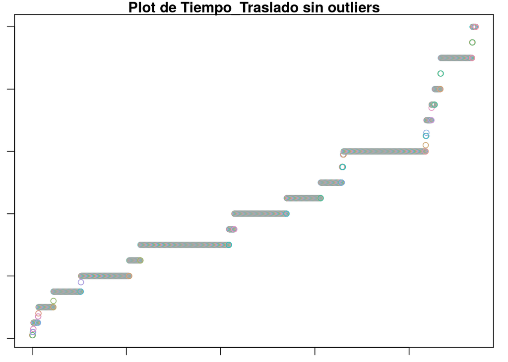

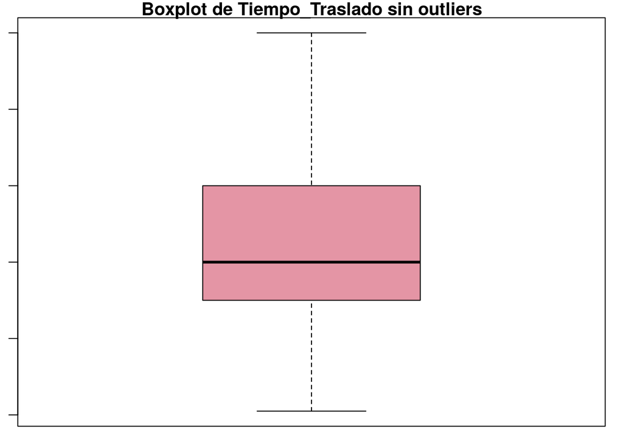

Modificando el outliers_max, remuevo el mas alejado de los outliers, y dejo los mas cercanos.

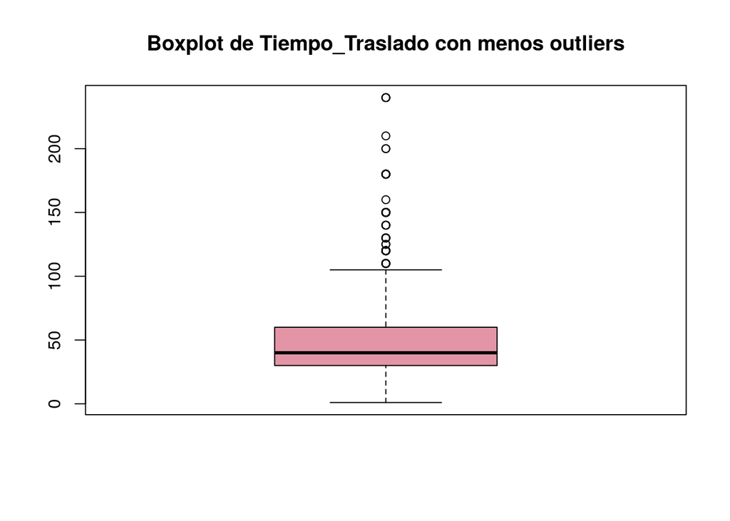

##### Método SD

Para obtener una distribución sin ningún outlier, para el atributo *Tiempo_Traslado* es necesario usar N=1

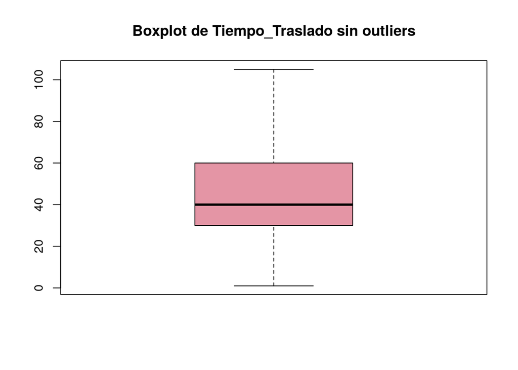

Para remover el outlier mas alejado y dejar los mas cercanos, tal como mostramos en método anterior, es necesario usar un N=4

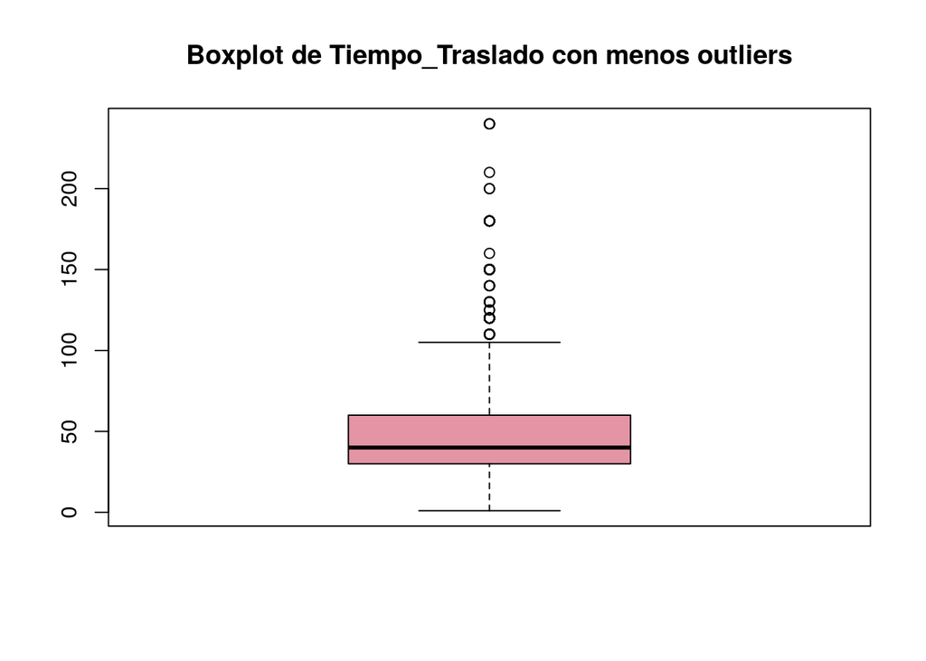

##### Método Z-Score

Para remover todos los *outliers* se utilizó un umbral de 100.

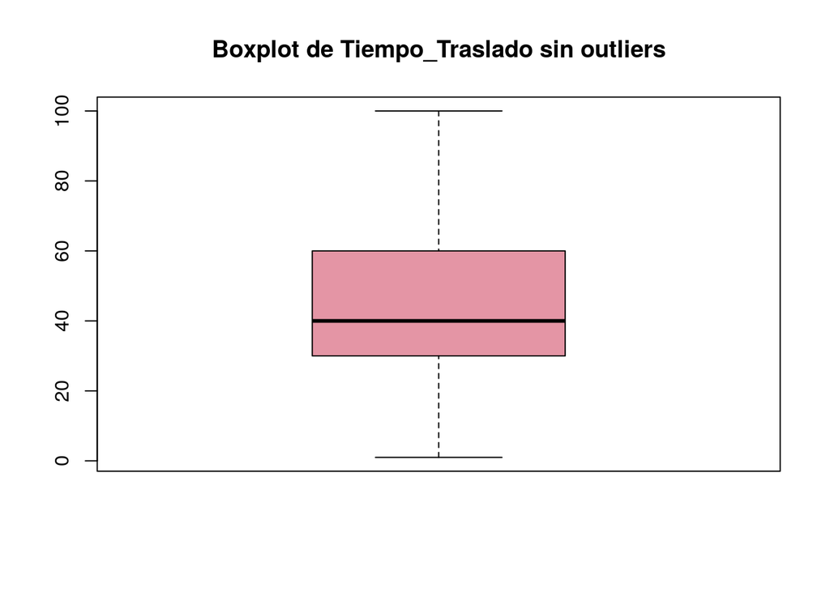

Al igual que en los métodos anteriores, para dejar solo los *outliers* mas cercanos, se determinó que el umbral debía ser de 250.

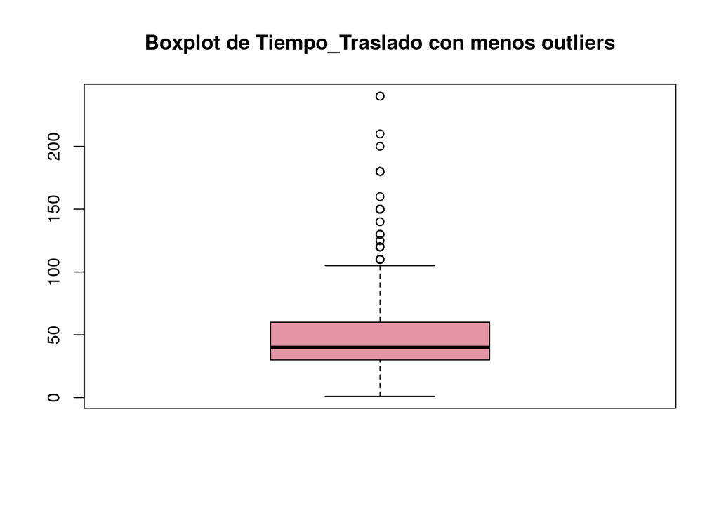

#### c. Concluya respecto a los resultados obtenidos con cada técnica.

Los resultados obtenidos con cada técnica son prácticamente los mismos, la diferencia que noté es que en el método de Z-Score, tuve mayor facilidad para parametrizar los umbrales en los que quería remover los outliers. Sin embargo, en los métodos de IRQ y SD, es un poco menos sencilla, dado que es prueba y error hasta encontrar que los outliers se remueven de la manera que estaba buscando. En el caso de Z-Score, como el score lo agrego como un atributo del dataframe, puedo ordenar de mayor a menor los Tiempos de Traslado, ver los score que tienen las primeras filas, y guiarme para establecer un umbral correcto.

### 3. Reducción de dimensionalidad

#### a. Evalúe la relación entre atributos a partir del coeficiente de correlación de Pearson y un análisis gráfico de heatmap para estudiar la posibilidad de eliminar redundancia en el dataset. En caso de corresponder, aplique las técnicas de Reducing Highly Correlated Columns trabajadas en clase.

Coeficientes de Correlación de Pearson entre cada uno de los atributos.

```
##       X1    X2    X3    X4    X5    X6    X7    X8
## X1  1.00 -0.78 -0.81 -0.78 -0.83  0.42  0.58  0.57
## X2 -0.78  1.00  0.95  0.84  0.90 -0.50 -0.35 -0.57
## X3 -0.81  0.95  1.00  0.90  0.93 -0.54 -0.37 -0.61
## X4 -0.78  0.84  0.90  1.00  0.86 -0.69 -0.42 -0.46
## X5 -0.83  0.90  0.93  0.86  1.00 -0.42 -0.31 -0.59
## X6  0.42 -0.50 -0.54 -0.69 -0.42  1.00  0.29  0.21
## X7  0.58 -0.35 -0.37 -0.42 -0.31  0.29  1.00  0.18
## X8  0.57 -0.57 -0.61 -0.46 -0.59  0.21  0.18  1.00
```

**Observaciones:**

- Hay un gran porcentaje de valores superiores a 0.70 o inferiores a -0.70.
- El atributo X2 y X3 presentan 0.95 de correlación.
- El atributo X2 y X5 presentan 0.90 de correlación.
- El atributo X3 y X4 presentan 0.90 de correlación.
- El atributo X3 y X5 presentan 0.93 de correlación.

Análisis gráfico de Heatmap

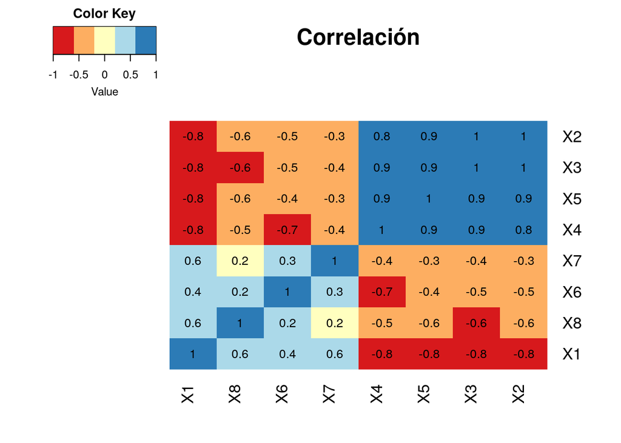

**Observaciones**

Comprobamos lo dicho anteriormente utilizando *findCorrelation* de la librería *caret*.

```
## [1] 3 4 2 5
```

Decido dejar unicamente el atributo X3, ya que es el que la suma de las correlaciones da el mayor numero, por lo tanto tendría la menor pérdida de información dejando este atributo.

El dataset quedaría de la siguiente manera:

```
## # A tibble: 6 × 5
##      X1    X3    X6    X7    X8
##   <dbl> <dbl> <dbl> <dbl> <dbl>
## 1    18   307  12      70     1
## 2    15   350  11.5    70     1
## 3    18   318  11      70     1
## 4    16   304  12      70     1
## 5    17   302  10.5    70     1
## 6    15   429  10      70     1
```

El heatmap luego de eliminar los atributos sería:

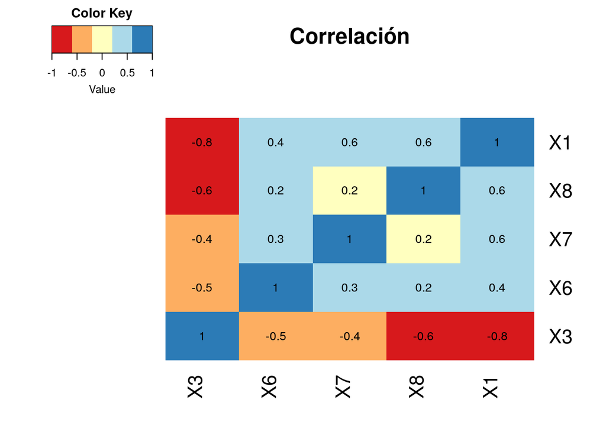

Si además eliminamos el atributo X1 ya que posee una correlación de -0.80 con el atributo X3.

El heatmap queda de la siguiente manera:

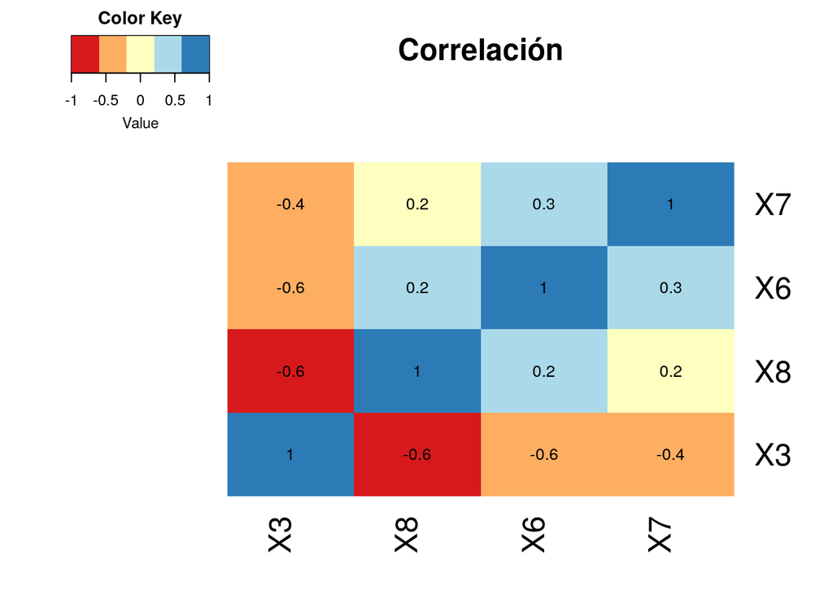

#### b. Verifique a través del Test de Chi-Cuadrado si existe dependencia entre pares de atributos discretos. Determine en qué casos es conveniente reducir la dimensionalidad.

Al haber leído los atributos con separador *whitespace*, el modelo del auto quedó separado en 2 atributos, luego de unirlos, el head del dataframe queda de la siguiente manera.

```
## # A tibble: 6 × 10
##      X1    X2    X3    X4    X5    X6    X7    X8 X9        X10
##   <dbl> <dbl> <dbl> <dbl> <dbl> <dbl> <dbl> <dbl> <chr>     <chr>
## 1    18     8   307   130  3504  12      70     1 chevrolet chevelle malibu
## 2    15     8   350   165  3693  11.5    70     1 buick     skylark 320
## 3    18     8   318   150  3436  11      70     1 plymouth  satellite NA
## 4    16     8   304   150  3433  12      70     1 amc       rebel sst
## 5    17     8   302   140  3449  10.5    70     1 ford      torino NA
## 6    15     8   429   198  4341  10      70     1 ford      galaxie 500
```

El test de chi cuadrado

```
##
##  Pearson's Chi-squared test
##
## data:  tbl_cont
## X-squared = 13858, df = 10767, p-value < 2.2e-16
```

### 5. Análisis de Componentes Principales

#### a. Calcule la matriz de covarianzas. ¿Qué nos indica la misma sobre los atributos del dataset?

```
##        Agr   Min    Fab   Ene   Con     IS   Fin    SSP    TC
## Agr 153.30  1.71 -36.69 -0.77 -3.26 -38.58 -4.00 -65.82 -5.82
## Min   1.71  0.97   2.69  0.13 -0.17  -2.02 -1.33  -2.13  0.14
## Fab -36.69  2.69  35.33  0.39  1.50   0.38 -5.59   0.96  0.79
## Ene  -0.77  0.13   0.39  0.12 -0.15   0.09  0.02   0.07  0.09
## Con  -3.26 -0.17   1.50 -0.15  1.57   0.99 -0.60  -0.04  0.15
## IS  -38.58 -2.02   0.38  0.09  0.99  19.20  3.91  15.89  0.12
## Fin  -4.00 -1.33  -5.59  0.02 -0.60   3.91  7.84   1.13 -1.42
## SSP -65.82 -2.13   0.96  0.07 -0.04  15.89  1.13  45.73  4.44
## TC   -5.82  0.14   0.79  0.09  0.15   0.12 -1.42   4.44  1.53
```

Los elementos de la diagonal de la matriz contienen las varianzas de las variables.

Los elementos que se encuentran fuera de la diagonal, contienen las covarianzas entre todos los pares de atributos del dataframe.

Es simetrica, ya que la covarianza entre AGR y SSP es la misma que la de SSP y AGR.

#### b. Realice ahora el análisis de componentes principales. ¿Cuánto explica de la variación total del dataset la primera componente? ¿Y si se incorpora la segunda? ¿Y el primer auto-valor?

```
## Importance of components:
##                           Comp.1    Comp.2    Comp.3    Comp.4     Comp.5
## Standard deviation     1.6342607 1.4673455 1.1765473 1.0460817 0.73977719
## Proportion of Variance 0.3091213 0.2492017 0.1602157 0.1266536 0.06334147
## Cumulative Proportion  0.3091213 0.5583230 0.7185387 0.8451923 0.90853375
##                            Comp.6     Comp.7     Comp.8       Comp.9
## Standard deviation     0.61934045 0.49662406 0.39999969 7.111610e-03
## Proportion of Variance 0.04439613 0.02854577 0.01851849 5.853587e-06
## Cumulative Proportion  0.95292989 0.98147566 0.99999415 1.000000e+00
```

La primera componente explica el 30% de la variación total del dataset.

Si se incorpora la segunda, se explica el 55% de la variación total del dataset.

En cuanto a los *loadings* :

```
##
## Loadings:
##     Comp.1 Comp.2 Comp.3 Comp.4 Comp.5 Comp.6 Comp.7 Comp.8 Comp.9
## Agr  0.560  0.163         0.208  0.139  0.113                0.760
## Min  0.252 -0.523 -0.132 -0.154               -0.771  0.152
## Fab -0.117 -0.468  0.124 -0.532 -0.340 -0.176  0.423         0.368
## Ene        -0.298 -0.618 -0.115  0.584         0.239 -0.333
## Con -0.141         0.678 -0.206  0.594 -0.198 -0.150 -0.239
## IS  -0.487  0.180        -0.235  0.179  0.606 -0.143  0.424  0.270
## Fin -0.115  0.476 -0.337 -0.282        -0.672 -0.172  0.221  0.173
## SSP -0.521                0.320 -0.286        -0.262 -0.542  0.411
## TC  -0.257 -0.360         0.597  0.224 -0.299  0.148  0.527
##
##                Comp.1 Comp.2 Comp.3 Comp.4 Comp.5 Comp.6 Comp.7 Comp.8 Comp.9
## SS loadings     1.000  1.000  1.000  1.000  1.000  1.000  1.000  1.000  1.000
## Proportion Var  0.111  0.111  0.111  0.111  0.111  0.111  0.111  0.111  0.111
## Cumulative Var  0.111  0.222  0.333  0.444  0.556  0.667  0.778  0.889  1.000
```

#### c. Grafique el perfil de variación de las componentes en un gráfico de dispersión donde las X es la componente y la Y la varianza.

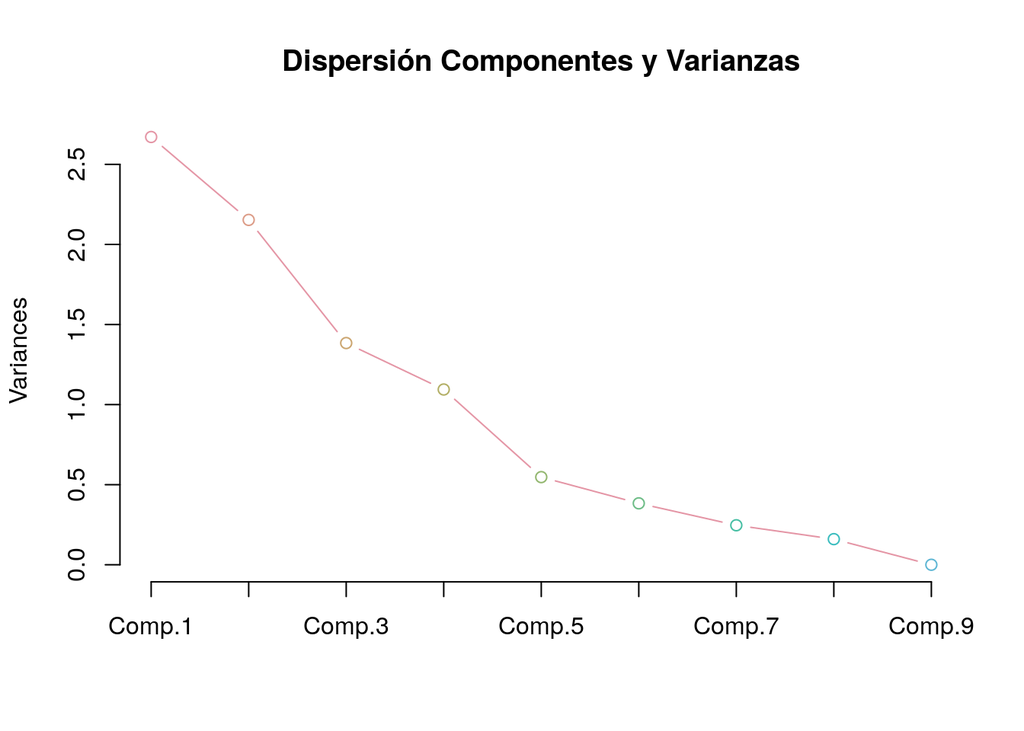

#### d. Analice la matriz de loading. ¿Qué información provee? ¿Qué variables están más correlacionadas con la primera componente?

La matriz de loadings provee la dirección del los vectores componentes.

Muestran a que variable está ams asociada cada Componente Principal.

```
##
## Loadings:
##     Comp.1 Comp.2 Comp.3 Comp.4 Comp.5 Comp.6 Comp.7 Comp.8 Comp.9
## Agr  0.560  0.163         0.208  0.139  0.113                0.760
## Min  0.252 -0.523 -0.132 -0.154               -0.771  0.152
## Fab -0.117 -0.468  0.124 -0.532 -0.340 -0.176  0.423         0.368
## Ene        -0.298 -0.618 -0.115  0.584         0.239 -0.333
## Con -0.141         0.678 -0.206  0.594 -0.198 -0.150 -0.239
## IS  -0.487  0.180        -0.235  0.179  0.606 -0.143  0.424  0.270
## Fin -0.115  0.476 -0.337 -0.282        -0.672 -0.172  0.221  0.173
## SSP -0.521                0.320 -0.286        -0.262 -0.542  0.411
## TC  -0.257 -0.360         0.597  0.224 -0.299  0.148  0.527
##
##                Comp.1 Comp.2 Comp.3 Comp.4 Comp.5 Comp.6 Comp.7 Comp.8 Comp.9
## SS loadings     1.000  1.000  1.000  1.000  1.000  1.000  1.000  1.000  1.000
## Proportion Var  0.111  0.111  0.111  0.111  0.111  0.111  0.111  0.111  0.111
## Cumulative Var  0.111  0.222  0.333  0.444  0.556  0.667  0.778  0.889  1.000
```

La variable *Agr* es la que está mas correlacionada positivamente con la primera componente (56%). Quiere decir que es fundamentalmente el procentaje de la población dedicada a la agricultura.

La variable *SSP* es la que está mas correlacionada negativamente con la primera componente (-52%).

#### e. Genere un gráfico de biplot y explique brevemente que información le provee el mismo.

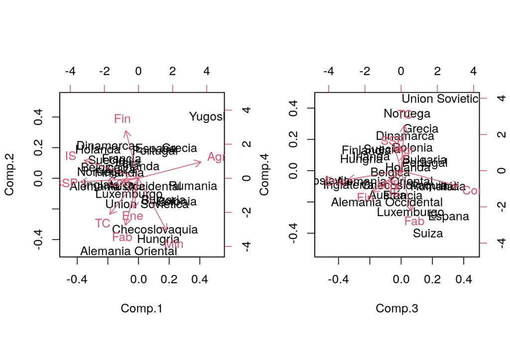

En las X provee los scores de la 1ra y 3ra componente principal. Las variables originales se representan mediante flechas, indican gráficamente la proporción de la varianza original explicada por las cuatro primeras componentes principales. La dirección de estas flechas indica los loadings relativos. Las escalas para los scores se encuentran abajo y a la izquierda. Las escalas para las variables están arriba y a la derecha.

La flecha más larga corresponde al *Agr* ya que tiene gran influencia (loading) como se indicó en el punto anterior.

En cuanto a las componentes 3 y 4, las variables con mayor influencia son *Ene*, *Con*, *Tc*, *Fab* y *Fin*

Los ejes más importantes corresponden a los sectores agrícola, manufacturero y de servicios.

Se distinguen 3 grupos de países. Aquellos con alto porcentaje de la población dedicado a la agricultura (España, Portugal, Yugoslavia y Grecia). Países con alto porcentaje de la población dedicada al sector de servicios y Financiero (Dinamarca y Holanda) Países con alto porcentaje de la población dedicado al sector manufacturero (Alemania Oriental, Checoslovaquia y Hungría)

#### f. En función de los análisis realizados en los puntos anteriores. ¿Cuántas componentes principales elegiría para explicar el comportamiento del dataset? Justifique esa cantidad.

Para explicar el comportamiento del dataset utilizaría 4 componentes.

La justificación es que, si las primeras 4 o 5 componentes explican el 80% de la varianza o superior, el problema puede ser tratado con componentes principales ya que se trata de una correlación lineal entre las variables. Si en la cantidad de componentes mencionada anteriormente, no se cuenta con el 80% de la varianza, sino que esta aumenta muy poco a medida se agregan nuevas componentes, debo considerar utilizar otro método, ya que no estaría utilizando el correcto.

Es decir, utilizo 4 componentes porque explican el 84% de la varianza del dataset, la cual al ser mayor a 80% es suficiente para explicar el comportamiento del dataset.

## Transformación de datos:

### 6. Discretización

#### a. Transforme el atributo a discreto, definiendo 5 rangos de acuerdo al análisis de frecuencia de los valores encontrados para el atributo.

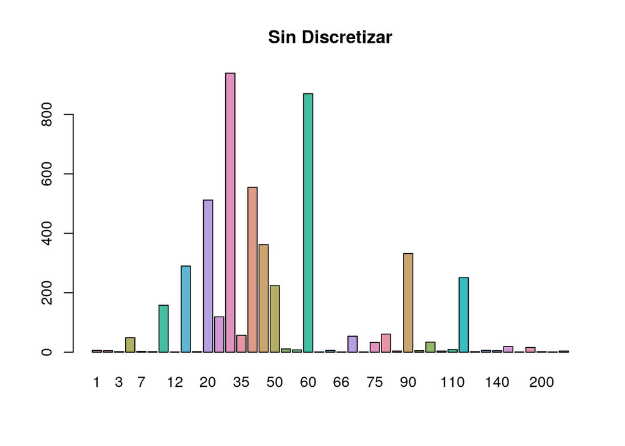

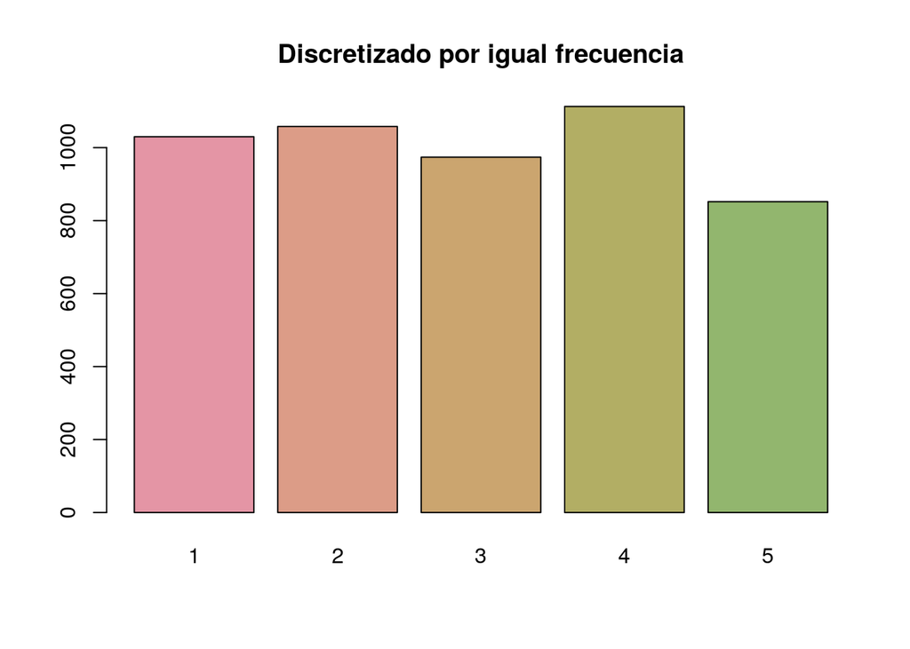

#### b. Transforme el atributo a discreto, definiendo 5 rangos de acuerdo al método de anchos iguales.

Mirando el barplot graficado en el punto anterior el cual pertenece a la variable antes de discretizar, se puede comparar con el siguiente, discretizado por anchos iguales.

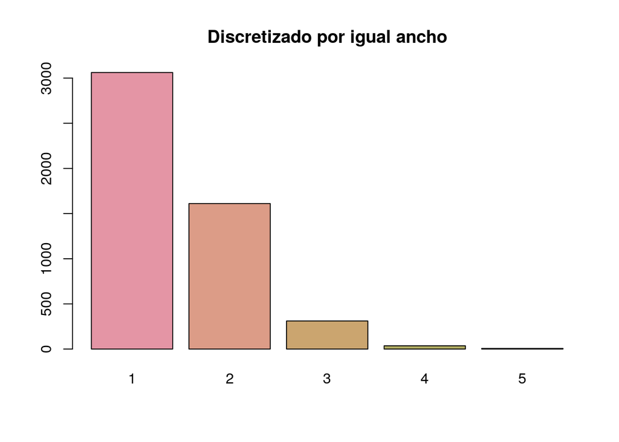

#### c. Transforme el atributo a discreto, definiendo usted, según su criterio, 5 rangos distintos con sus respectivas etiquetas.

Los rangos definidos son:

1. “**Muy poco**”: hasta 15 min
2. “**Poco**”: entre 15 y 35 min
3. “**Medio**”: entre 35 y 60 min
4. “**Alto**”: entre 60 y 90 min
5. “**Muy alto**”: más de 90 min

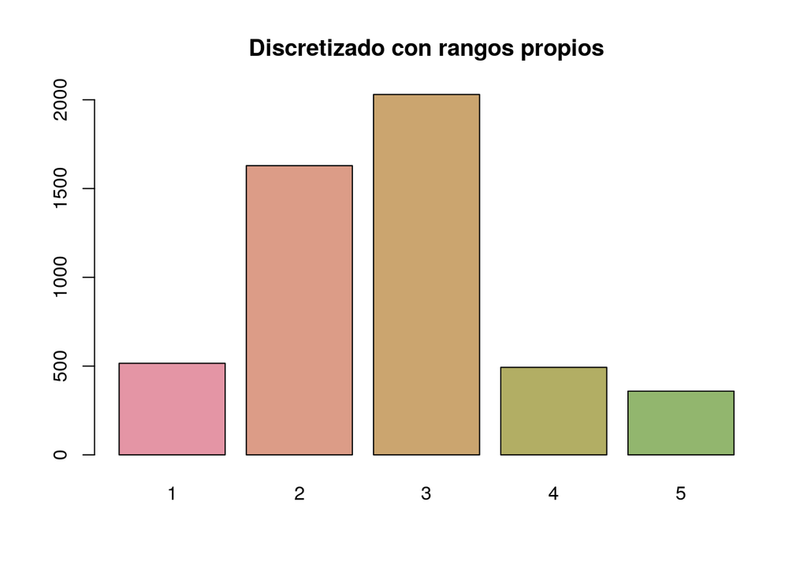

#### d. Analice los resultados encontrados. Compare los mismos realizando gráficos de frecuencia sobre los intervalos resultantes en cada caso. ¿Qué conclusiones se pueden obtener en términos del balanceo de las mismas de acuerdo a la técnica utilizada?

La discretización por igual frecuencia genera una cantidad de valores de cada rango similar, lo cual de manera rápida y visual no me provee demasiada información sobre los valores de los tiempos de traslado.

En cuanto a la discretización por igual ancho, la distribución se asemeja a la de la variable original, la mayor cantidad de valores con una asimetría positiva. Parece correcta esta discretización, pasamos de una variable continua a una discreta, manteniendo las características de la variable original.

La discretización mediante rangos definidos, tiene una similitud con la distribución normal, con una gran cantidad de valores concentrados en el centro, pero la variable original no seguía estas características. Pero me pareció interesante poder definir a criterio mio los rangos de valores por los cuales me resulta útil discretizar los datos, la desventaja de esto seguramente sea la escalabilidad, con un rango amplio de valores, es mejor optar por las técnicas anteriores. Además, es bastante subjetiva la definición de los intervalos, ya que para otras personas, un viaje de 60 o 90 minutos, podrían no resultarles un *tiempo_traslado* *Alto*.

### 7. Normalización

#### a. A partir del dataset encuesta_universitaria.csv, opere sobre el atributo tiempo_traslado de la siguiente manera:

##### i. Normalice el atributo utilizando la técnica de mínimo-máximo.

```
##  [1] 0.16317992 0.37238494 0.12133891 0.07949791 0.16317992 0.12133891
##  [7] 0.49790795 0.12133891 0.20502092 0.24686192
```

##### ii. Ahora, normalice el atributo mediante la técnica de z-score propuesta en el libro “Data Mining. Concepts & Techniques de Jiawei Han & otros”.

```
##  [1] -0.25102485  1.40540567 -0.58231095 -0.91359705 -0.25102485 -0.58231095
##  [7]  2.39926398 -0.58231095  0.08026126  0.41154736
```

##### iii. Por último, utilice la técnica de escalado decimal para llevar adelante la tarea de normalización.

```
##  [1] 0.04 0.09 0.03 0.02 0.04 0.03 0.12 0.03 0.05 0.06
```